# Diff-in-Diff Borusyak: AGC Changed-Block Outcomes

# 1 Purpose

This notebook estimates the effect of observed Cursor adoption on the repository-month share of AI-generated-like code among newly added or structurally modified top-level Python function and class blocks. It uses the Borusyak et al. imputation difference-in-differences estimator.

The primary flow-based outcome is:

$$\text{AGC changed-block ratio}_{it}
=
\frac{\text{changed AGC blocks}_{it}}
{\text{changed AGC blocks}_{it}+\text{changed HWC blocks}_{it}}$$

where:

- **AGC** means AI likely generated code.
- **HWC** means Human likely written code.
- Changed blocks include only newly added or structurally modified current top-level blocks.
- Unchanged blocks, moved-but-structurally-unchanged blocks, and deleted blocks are excluded.

The stock-based analysis measures the accumulated structural composition of each repository snapshot and is retained as a baseline analysis. This changed-block analysis focuses on current-period code flow to reduce dilution from unchanged legacy code.

The detector outcome captures structural patterns associated with AI-generated code. It does not establish the actual provenance of individual blocks or identify which AI tool generated or assisted with them.

The primary estimand is the average change in the repository-month AGC changed-block ratio after first observed Cursor adoption, relative to contemporaneous changes in matched repositories with no observed Cursor adoption during the study period.

The adjusted specifications additionally include contemporaneous monthly development activity measured by `log1p(commits)` and `log1p(lines_added)`. Because commits and added lines may themselves respond to Cursor adoption, these activity-adjusted estimates are treated as conditional sensitivity analyses. The unadjusted specification remains the closest estimate of the total post-adoption change in the outcome.

# 2 Load Packages and Helper Functions

```r
library(data.table)
library(dplyr)
```

```r
library(ggplot2)
library(didimputation)
library(jsonlite)

if (!file.exists(helper_path)) {
  stop("Borusyak helper file not found: ", helper_path)
}

source(helper_path)
```

# 3 Utility Functions

```r
normalize_yyyymm <- function(x) {
  x <- as.character(x)
  x[x %in% c("", "NA", "NaN", "NULL", "None")] <- NA_character_
  x <- gsub("-", "", x)
  suppressWarnings(as.integer(x))
}

yyyymm_to_month_id <- function(x) {
  x <- as.integer(x)
  year <- x %/% 100L
  month <- x %% 100L

  out <- year * 12L + month
  out[is.na(x) | month < 1L | month > 12L] <- NA_integer_
  out
}

require_columns <- function(data, required, label) {
  missing <- setdiff(required, names(data))
  if (length(missing) > 0) {
    stop(label, " missing required columns: ", paste(missing, collapse = ", "))
  }
}

numeric_if_present <- function(data, columns) {
  for (column_name in intersect(columns, names(data))) {
    set(
      data,
      j = column_name,
      value = suppressWarnings(as.numeric(data[[column_name]]))
    )
  }

  invisible(data)
}

safe_ratio <- function(numerator, denominator) {
  out <- rep(NA_real_, length(denominator))
  valid <- !is.na(numerator) & !is.na(denominator) & denominator > 0
  out[valid] <- numerator[valid] / denominator[valid]
  out
}

count_mismatch <- function(left, right, tolerance = 1e-12) {
  comparable <- !is.na(left) & !is.na(right)
  sum(comparable & abs(left - right) > tolerance)
}

empty_model_error_table <- function() {
  data.frame(
    panel = character(),
    specification = character(),
    outcome = character(),
    model_type = character(),
    error = character(),
    stringsAsFactors = FALSE
  )
}

build_first_stage_formula <- function(specification) {
  if (identical(specification, "unadjusted")) {
    return(~ 1 | repo_id + time_id)
  }

  ~ age_log + ncloc_model + contributors_log + stars_log + issues_log +
    commits_log + lines_added_log | repo_id + time_id
}
```

# 4 Validate the Upstream Input

```r
cat("Project root:", project_root, "\n")
```

```
## Project root: /home/user1-system12/project-workspace/ai_code_complexity_study_python/ai-code-complexity-study
```

```r
cat("Panel path:", panel_path, "\n")
```

```
## Panel path: /home/user1-system12/project-workspace/ai_code_complexity_study_python/ai-code-complexity-study/repo_python/run-py-4a/strict/panel_event_monthly_agc_changed_block_py.csv
```

```r
cat("Validation summary:", validation_summary_path, "\n")
```

```
## Validation summary: /home/user1-system12/project-workspace/ai_code_complexity_study_python/ai-code-complexity-study/repo_python/tmp/run-py-4b/strict/agc_changed_block_panel_validation_summary.json
```

```r
cat("Output directory:", out_dir, "\n")
```

```
## Output directory: /home/user1-system12/project-workspace/ai_code_complexity_study_python/ai-code-complexity-study/repo_python/run-py-4c/strict
```

```r
cat("Panel label:", panel_label, "\n")
```

```
## Panel label: strict
```

```r
if (!file.exists(panel_path)) {
  stop("AGC changed-block panel not found: ", panel_path)
}

if (!file.exists(validation_summary_path)) {
  stop("run-py-4b validation summary not found: ", validation_summary_path)
}

validation_summary <- jsonlite::fromJSON(validation_summary_path)

if (is.null(validation_summary$status) || validation_summary$status != "PASS") {
  stop(
    "run-py-4b validation status must be PASS. Found: ",
    validation_summary$status
  )
}

if (!is.null(validation_summary$checks_failed) &&
    as.integer(validation_summary$checks_failed) != 0L) {
  stop(
    "run-py-4b validation reports failed checks: ",
    validation_summary$checks_failed
  )
}

cat("Validated upstream rows:", validation_summary$panel_rows, "\n")
```

```
## Validated upstream rows: 1633
```

```r
cat("Validated upstream repositories:", validation_summary$repositories, "\n")
```

```
## Validated upstream repositories: 220
```

```r
cat("Validated changed blocks:", validation_summary$changed_top_level_blocks, "\n")
```

```
## Validated changed blocks: 163540
```

```r
cat("Validated ratio rows:", validation_summary$repo_months_with_primary_ratio, "\n")
```

```
## Validated ratio rows: 1127
```

```r
cat("Validated upstream checks:", validation_summary$checks_passed,
    "/", validation_summary$checks_total, "\n")
```

```
## Validated upstream checks: 65 / 65
```

# 5 Load and Normalize the Changed-Block Panel

```r
panel_raw <- fread(panel_path)

required_columns <- c(
  "repo_name",
  "time",
  "dataset_source",
  "event",
  "post_event",
  "time_to_event",
  "is_treatment",
  "commits",
  "lines_added",
  "contributors",
  "stars",
  "issues",
  "age",
  "ncloc_paper",
  "ncloc_python_snapshot",
  "changed_top_level_blocks",
  "changed_agc_top_level_blocks",
  "changed_hwc_top_level_blocks",
  "agc_changed_top_level_block_ratio",
  "added_top_level_blocks",
  "added_agc_top_level_blocks",
  "added_hwc_top_level_blocks",
  "agc_added_top_level_block_ratio",
  "modified_top_level_blocks",
  "modified_agc_top_level_blocks",
  "modified_hwc_top_level_blocks",
  "agc_modified_top_level_block_ratio",
  "changed_function_blocks",
  "changed_agc_function_blocks",
  "changed_hwc_function_blocks",
  "agc_changed_function_block_ratio",
  "changed_class_blocks",
  "changed_agc_class_blocks",
  "changed_hwc_class_blocks",
  "agc_changed_class_block_ratio"
)

require_columns(panel_raw, required_columns, "AGC changed-block panel")

numeric_columns <- setdiff(required_columns, c(
  "repo_name",
  "time",
  "dataset_source",
  "event"
))
numeric_if_present(panel_raw, numeric_columns)

panel_raw[, time_yyyymm := normalize_yyyymm(time)]
panel_raw[, event_yyyymm := normalize_yyyymm(event)]
panel_raw[dataset_source == "control", event_yyyymm := 0L]

panel_raw[, time_id := yyyymm_to_month_id(time_yyyymm)]
panel_raw[, event_id := fifelse(
  dataset_source == "control",
  0L,
  yyyymm_to_month_id(event_yyyymm)
)]

panel_raw[, repo_name_str := repo_name]
panel_raw[, repo_id := as.integer(factor(repo_name_str))]
panel_raw[, ever_treated := as.integer(dataset_source == "treatment")]
panel_raw[, analysis_group := fifelse(
  dataset_source == "control",
  "control",
  fifelse(post_event == 1, "treatment_post", "treatment_pre")
)]

panel_raw[, age_log := fifelse(!is.na(age) & age >= 0, log1p(age), NA_real_)]
panel_raw[, commits_log := fifelse(
  !is.na(commits) & commits >= 0,
  log1p(commits),
  NA_real_
)]
panel_raw[, lines_added_log := fifelse(
  !is.na(lines_added) & lines_added >= 0,
  log1p(lines_added),
  NA_real_
)]
panel_raw[, contributors_log := fifelse(
  !is.na(contributors) & contributors >= 0,
  log1p(contributors),
  NA_real_
)]
panel_raw[, stars_log := fifelse(
  !is.na(stars) & stars >= 0,
  log1p(stars),
  NA_real_
)]
panel_raw[, issues_log := fifelse(
  !is.na(issues) & issues >= 0,
  log1p(issues),
  NA_real_
)]

cat("Loaded rows:", nrow(panel_raw), "\n")
```

```
## Loaded rows: 1633
```

```r
cat("Loaded repositories:", uniqueN(panel_raw$repo_name), "\n")
```

```
## Loaded repositories: 220
```

```r
cat("Treatment rows:", sum(panel_raw$dataset_source == "treatment"), "\n")
```

```
## Treatment rows: 853
```

```r
cat("Control rows:", sum(panel_raw$dataset_source == "control"), "\n")
```

```
## Control rows: 780
```

```r
cat("Primary ratio rows:", sum(!is.na(panel_raw$agc_changed_top_level_block_ratio)), "\n")
```

```
## Primary ratio rows: 1127
```

```r
cat("Calendar range:", min(panel_raw$time, na.rm = TRUE), "to",
    max(panel_raw$time, na.rm = TRUE), "\n")
```

```
## Calendar range: 2024-01 to 2025-08
```

# 6 Panel and Outcome Sanity Checks

```r
key_columns <- c("repo_name", "time", "dataset_source")
duplicate_keys <- duplicated(panel_raw, by = key_columns)

recomputed_time_to_event <- rep(NA_real_, nrow(panel_raw))
treated_idx <- panel_raw$dataset_source == "treatment"
recomputed_time_to_event[treated_idx] <-
  panel_raw$time_id[treated_idx] - panel_raw$event_id[treated_idx]

changed_count_mismatch <- count_mismatch(
  panel_raw$changed_top_level_blocks,
  panel_raw$changed_agc_top_level_blocks + panel_raw$changed_hwc_top_level_blocks
)
changed_scope_mismatch <- count_mismatch(
  panel_raw$changed_top_level_blocks,
  panel_raw$added_top_level_blocks + panel_raw$modified_top_level_blocks
)
changed_agc_scope_mismatch <- count_mismatch(
  panel_raw$changed_agc_top_level_blocks,
  panel_raw$added_agc_top_level_blocks + panel_raw$modified_agc_top_level_blocks
)
changed_hwc_scope_mismatch <- count_mismatch(
  panel_raw$changed_hwc_top_level_blocks,
  panel_raw$added_hwc_top_level_blocks + panel_raw$modified_hwc_top_level_blocks
)
changed_kind_mismatch <- count_mismatch(
  panel_raw$changed_top_level_blocks,
  panel_raw$changed_function_blocks + panel_raw$changed_class_blocks
)
changed_agc_kind_mismatch <- count_mismatch(
  panel_raw$changed_agc_top_level_blocks,
  panel_raw$changed_agc_function_blocks + panel_raw$changed_agc_class_blocks
)
changed_hwc_kind_mismatch <- count_mismatch(
  panel_raw$changed_hwc_top_level_blocks,
  panel_raw$changed_hwc_function_blocks + panel_raw$changed_hwc_class_blocks
)

primary_ratio_recomputed <- safe_ratio(
  panel_raw$changed_agc_top_level_blocks,
  panel_raw$changed_top_level_blocks
)
function_ratio_recomputed <- safe_ratio(
  panel_raw$changed_agc_function_blocks,
  panel_raw$changed_function_blocks
)
class_ratio_recomputed <- safe_ratio(
  panel_raw$changed_agc_class_blocks,
  panel_raw$changed_class_blocks
)

panel_checks <- data.frame(
  check = c(
    "panel_label",
    "rows",
    "repositories",
    "treatment_rows",
    "control_rows",
    "treatment_repositories",
    "control_repositories",
    "duplicate_keys",
    "time_id_missing",
    "treatment_event_id_missing",
    "control_event_id_nonzero",
    "is_treatment_post_event_mismatch",
    "time_to_event_mismatch",
    "changed_agc_plus_hwc_mismatch",
    "changed_added_plus_modified_mismatch",
    "changed_agc_added_plus_modified_mismatch",
    "changed_hwc_added_plus_modified_mismatch",
    "changed_function_plus_class_mismatch",
    "changed_agc_function_plus_class_mismatch",
    "changed_hwc_function_plus_class_mismatch",
    "primary_ratio_mismatch",
    "function_ratio_mismatch",
    "class_ratio_mismatch",
    "primary_ratio_outside_unit_interval",
    "function_ratio_outside_unit_interval",
    "class_ratio_outside_unit_interval",
    "primary_ratio_rows",
    "commits_nonmissing",
    "lines_added_nonmissing",
    "commits_negative",
    "lines_added_negative",
    "ncloc_paper_nonmissing",
    "ncloc_python_snapshot_nonmissing",
    "upstream_validation_status",
    "upstream_checks_failed"
  ),
  value = c(
    panel_label,
    nrow(panel_raw),
    uniqueN(panel_raw$repo_name),
    sum(panel_raw$dataset_source == "treatment"),
    sum(panel_raw$dataset_source == "control"),
    uniqueN(panel_raw[dataset_source == "treatment", repo_name]),
    uniqueN(panel_raw[dataset_source == "control", repo_name]),
    sum(duplicate_keys),
    sum(is.na(panel_raw$time_id)),
    sum(panel_raw$dataset_source == "treatment" & is.na(panel_raw$event_id)),
    sum(panel_raw$dataset_source == "control" & panel_raw$event_id != 0L),
    sum(panel_raw$is_treatment != panel_raw$post_event, na.rm = TRUE),
    sum(
      panel_raw$dataset_source == "treatment" &
        !is.na(panel_raw$time_to_event) &
        panel_raw$time_to_event != recomputed_time_to_event,
      na.rm = TRUE
    ),
    changed_count_mismatch,
    changed_scope_mismatch,
    changed_agc_scope_mismatch,
    changed_hwc_scope_mismatch,
    changed_kind_mismatch,
    changed_agc_kind_mismatch,
    changed_hwc_kind_mismatch,
    count_mismatch(panel_raw$agc_changed_top_level_block_ratio, primary_ratio_recomputed),
    count_mismatch(panel_raw$agc_changed_function_block_ratio, function_ratio_recomputed),
    count_mismatch(panel_raw$agc_changed_class_block_ratio, class_ratio_recomputed),
    sum(
      !is.na(panel_raw$agc_changed_top_level_block_ratio) &
        (panel_raw$agc_changed_top_level_block_ratio < 0 |
           panel_raw$agc_changed_top_level_block_ratio > 1)
    ),
    sum(
      !is.na(panel_raw$agc_changed_function_block_ratio) &
        (panel_raw$agc_changed_function_block_ratio < 0 |
           panel_raw$agc_changed_function_block_ratio > 1)
    ),
    sum(
      !is.na(panel_raw$agc_changed_class_block_ratio) &
        (panel_raw$agc_changed_class_block_ratio < 0 |
           panel_raw$agc_changed_class_block_ratio > 1)
    ),
    sum(!is.na(panel_raw$agc_changed_top_level_block_ratio)),
    sum(!is.na(panel_raw$commits)),
    sum(!is.na(panel_raw$lines_added)),
    sum(panel_raw$commits < 0, na.rm = TRUE),
    sum(panel_raw$lines_added < 0, na.rm = TRUE),
    sum(!is.na(panel_raw$ncloc_paper)),
    sum(!is.na(panel_raw$ncloc_python_snapshot)),
    validation_summary$status,
    validation_summary$checks_failed
  ),
  stringsAsFactors = FALSE
)

print(panel_checks)
```

```
##                                       check  value
## 1                               panel_label strict
## 2                                      rows   1633
## 3                              repositories    220
## 4                            treatment_rows    853
## 5                              control_rows    780
## 6                    treatment_repositories    100
## 7                      control_repositories    120
## 8                            duplicate_keys      0
## 9                           time_id_missing      0
## 10               treatment_event_id_missing      0
## 11                 control_event_id_nonzero      0
## 12         is_treatment_post_event_mismatch      0
## 13                   time_to_event_mismatch      0
## 14            changed_agc_plus_hwc_mismatch      0
```

[output cut: 21 more lines]

```r
fwrite(
  panel_checks,
  file.path(out_dir, "borusyak_agc_changed_block_panel_checks.csv")
)

hard_failure_checks <- c(
  sum(duplicate_keys),
  sum(is.na(panel_raw$time_id)),
  sum(panel_raw$dataset_source == "treatment" & is.na(panel_raw$event_id)),
  sum(panel_raw$dataset_source == "control" & panel_raw$event_id != 0L),
  sum(panel_raw$is_treatment != panel_raw$post_event, na.rm = TRUE),
  changed_count_mismatch,
  changed_scope_mismatch,
  changed_agc_scope_mismatch,
  changed_hwc_scope_mismatch,
  changed_kind_mismatch,
  changed_agc_kind_mismatch,
  changed_hwc_kind_mismatch,
  count_mismatch(panel_raw$agc_changed_top_level_block_ratio, primary_ratio_recomputed),
  count_mismatch(panel_raw$agc_changed_function_block_ratio, function_ratio_recomputed),
  count_mismatch(panel_raw$agc_changed_class_block_ratio, class_ratio_recomputed),
  sum(panel_raw$commits < 0, na.rm = TRUE),
  sum(panel_raw$lines_added < 0, na.rm = TRUE)
)

if (any(hard_failure_checks != 0)) {
  stop(
    "AGC changed-block panel sanity checks failed. See ",
    "borusyak_agc_changed_block_panel_checks.csv."
  )
}

if (!is.null(validation_summary$panel_rows) &&
    nrow(panel_raw) != as.integer(validation_summary$panel_rows)) {
  stop("Panel row count differs from the run-py-4b validation summary.")
}

if (!is.null(validation_summary$repo_months_with_primary_ratio) &&
    sum(!is.na(panel_raw$agc_changed_top_level_block_ratio)) !=
      as.integer(validation_summary$repo_months_with_primary_ratio)) {
  stop("Primary ratio row count differs from the run-py-4b validation summary.")
}
```

# 7 Ratio Coverage Diagnostics

```r
outcome_definitions <- data.frame(
  outcome = c(
    "agc_changed_top_level_block_ratio",
    "agc_changed_function_block_ratio",
    "agc_changed_class_block_ratio"
  ),
  outcome_label = c(
    "AGC-Like Changed Top-Level Block Share",
    "AGC-Like Changed Function Block Share",
    "AGC-Like Changed Class Block Share"
  ),
  denominator = c(
    "changed_top_level_blocks",
    "changed_function_blocks",
    "changed_class_blocks"
  ),
  role = c("primary", "robustness", "robustness"),
  stringsAsFactors = FALSE
)

coverage_rows <- list()
for (outcome_index in seq_len(nrow(outcome_definitions))) {
  outcome_var <- outcome_definitions$outcome[outcome_index]
  outcome_label <- outcome_definitions$outcome_label[outcome_index]
  denominator_var <- outcome_definitions$denominator[outcome_index]

  coverage_part <- panel_raw[, .(
    total_rows = .N,
    ratio_rows = sum(!is.na(get(outcome_var))),
    missing_ratio_rows = sum(is.na(get(outcome_var))),
    positive_denominator_rows = sum(get(denominator_var) > 0, na.rm = TRUE),
    zero_denominator_rows = sum(get(denominator_var) == 0, na.rm = TRUE),
    denominator_sum = sum(get(denominator_var), na.rm = TRUE)
  ), by = analysis_group]

  coverage_part[, availability_rate := ratio_rows / total_rows]
  coverage_part[, outcome := outcome_var]
  coverage_part[, outcome_label := outcome_label]
  coverage_rows[[length(coverage_rows) + 1]] <- coverage_part
}

coverage_by_group <- rbindlist(coverage_rows, fill = TRUE)
setcolorder(
  coverage_by_group,
  c(
    "outcome",
    "outcome_label",
    "analysis_group",
    "total_rows",
    "ratio_rows",
    "missing_ratio_rows",
    "availability_rate",
    "positive_denominator_rows",
    "zero_denominator_rows",
    "denominator_sum"
  )
)

print(coverage_by_group)
```

```
##                              outcome                          outcome_label
##                               <char>                                 <char>
## 1: agc_changed_top_level_block_ratio AGC-Like Changed Top-Level Block Share
## 2: agc_changed_top_level_block_ratio AGC-Like Changed Top-Level Block Share
## 3: agc_changed_top_level_block_ratio AGC-Like Changed Top-Level Block Share
## 4:  agc_changed_function_block_ratio  AGC-Like Changed Function Block Share
## 5:  agc_changed_function_block_ratio  AGC-Like Changed Function Block Share
## 6:  agc_changed_function_block_ratio  AGC-Like Changed Function Block Share
## 7:     agc_changed_class_block_ratio     AGC-Like Changed Class Block Share
## 8:     agc_changed_class_block_ratio     AGC-Like Changed Class Block Share
## 9:     agc_changed_class_block_ratio     AGC-Like Changed Class Block Share
##    analysis_group total_rows ratio_rows missing_ratio_rows availability_rate
##            <char>      <int>      <int>              <int>             <num>
## 1: treatment_post        432        324                108         0.7500000
## 2:  treatment_pre        421        314                107         0.7458432
```

[output cut: 18 more lines]

```r
fwrite(
  coverage_by_group,
  file.path(out_dir, "borusyak_agc_changed_block_ratio_coverage_by_group.csv")
)

coverage_by_event_time <- panel_raw[dataset_source == "treatment", .(
  total_rows = .N,
  primary_ratio_rows = sum(!is.na(agc_changed_top_level_block_ratio)),
  primary_ratio_missing_rows = sum(is.na(agc_changed_top_level_block_ratio)),
  primary_ratio_availability_rate = mean(!is.na(agc_changed_top_level_block_ratio)),
  changed_top_level_blocks = sum(changed_top_level_blocks, na.rm = TRUE)
), by = time_to_event][order(time_to_event)]

print(coverage_by_event_time)
```

```
##     time_to_event total_rows primary_ratio_rows primary_ratio_missing_rows
##             <num>      <int>              <int>                      <int>
##  1:           -14         14                  0                         14
##  2:           -13         18                 13                          5
##  3:           -12         20                 17                          3
##  4:           -11         21                 17                          4
##  5:           -10         22                 17                          5
##  6:            -9         30                 22                          8
##  7:            -8         31                 23                          8
##  8:            -7         31                 24                          7
##  9:            -6         31                 21                         10
## 10:            -5         33                 27                          6
## 11:            -4         35                 31                          4
## 12:            -3         40                 33                          7
## 13:            -2         42                 34                          8
```

[output cut: 43 more lines]

```r
fwrite(
  coverage_by_event_time,
  file.path(out_dir, "borusyak_agc_changed_block_ratio_coverage_by_event_time.csv")
)
```

# 8 Outcomes and Model Specifications

```r
specification_definitions <- data.frame(
  specification = c(
    "unadjusted",
    "paper_ncloc",
    "python_snapshot_ncloc"
  ),
  specification_label = c(
    "Unadjusted",
    "Paper NCLOC + Activity",
    "Python Snapshot NCLOC + Activity"
  ),
  ncloc_column = c(
    NA_character_,
    "ncloc_paper",
    "ncloc_python_snapshot"
  ),
  stringsAsFactors = FALSE
)

print(outcome_definitions)
```

```
##                             outcome                          outcome_label
## 1 agc_changed_top_level_block_ratio AGC-Like Changed Top-Level Block Share
## 2  agc_changed_function_block_ratio  AGC-Like Changed Function Block Share
## 3     agc_changed_class_block_ratio     AGC-Like Changed Class Block Share
##                denominator       role
## 1 changed_top_level_blocks    primary
## 2  changed_function_blocks robustness
## 3     changed_class_blocks robustness
```

```r
print(specification_definitions)
```

```
##           specification              specification_label          ncloc_column
## 1            unadjusted                       Unadjusted                  <NA>
## 2           paper_ncloc           Paper NCLOC + Activity           ncloc_paper
## 3 python_snapshot_ncloc Python Snapshot NCLOC + Activity ncloc_python_snapshot
```

# 9 Prepare Common Outcome-Specific Samples

```r
common_covariates <- c(
  "age_log",
  "commits_log",
  "lines_added_log",
  "contributors_log",
  "stars_log",
  "issues_log",
  "ncloc_paper",
  "ncloc_python_snapshot"
)

common_samples <- list()
sample_summary_rows <- list()

for (outcome_index in seq_len(nrow(outcome_definitions))) {
  outcome_var <- outcome_definitions$outcome[outcome_index]
  outcome_label <- outcome_definitions$outcome_label[outcome_index]
  denominator_var <- outcome_definitions$denominator[outcome_index]
  outcome_role <- outcome_definitions$role[outcome_index]

  available_data <- copy(panel_raw[!is.na(get(outcome_var))])
  required <- c(
    "repo_id",
    "time_id",
    "event_id",
    "dataset_source",
    outcome_var,
    common_covariates
  )

  sample_data <- copy(panel_raw)
  sample_data <- sample_data[complete.cases(sample_data[, ..required])]

  if (nrow(sample_data) == 0) {
    stop("No complete rows remain for outcome: ", outcome_var)
  }

  sample_data[, sample_key := paste(repo_name, time, dataset_source, sep = "|")]
  common_samples[[outcome_var]] <- sample_data

  sample_summary_rows[[length(sample_summary_rows) + 1]] <- data.frame(
    outcome = outcome_var,
    outcome_label = outcome_label,
    role = outcome_role,
    denominator = denominator_var,
    panel_rows = nrow(panel_raw),
    outcome_available_rows = nrow(available_data),
    model_common_sample_rows = nrow(sample_data),
    rows_removed_for_common_covariates = nrow(available_data) - nrow(sample_data),
    repositories = uniqueN(sample_data$repo_id),
    treatment_rows = sum(sample_data$dataset_source == "treatment"),
    control_rows = sum(sample_data$dataset_source == "control"),
    treatment_pre_rows = sum(
      sample_data$dataset_source == "treatment" & sample_data$post_event == 0
    ),
    treatment_post_rows = sum(
      sample_data$dataset_source == "treatment" & sample_data$post_event == 1
    ),
    treatment_repositories = uniqueN(
      sample_data[dataset_source == "treatment", repo_id]
    ),
    control_repositories = uniqueN(
      sample_data[dataset_source == "control", repo_id]
    ),
    min_time = min(sample_data$time),
    max_time = max(sample_data$time),
    changed_blocks_in_sample = sum(sample_data[[denominator_var]], na.rm = TRUE),
    stringsAsFactors = FALSE
  )
}

sample_summary <- bind_rows(sample_summary_rows)
print(sample_summary)
```

```
##                             outcome                          outcome_label
## 1 agc_changed_top_level_block_ratio AGC-Like Changed Top-Level Block Share
## 2  agc_changed_function_block_ratio  AGC-Like Changed Function Block Share
## 3     agc_changed_class_block_ratio     AGC-Like Changed Class Block Share
##         role              denominator panel_rows outcome_available_rows
## 1    primary changed_top_level_blocks       1633                   1127
## 2 robustness  changed_function_blocks       1633                   1020
## 3 robustness     changed_class_blocks       1633                    994
##   model_common_sample_rows rows_removed_for_common_covariates repositories
## 1                     1123                                  4          166
## 2                     1016                                  4          158
## 3                      990                                  4          148
##   treatment_rows control_rows treatment_pre_rows treatment_post_rows
## 1            634          489                314                 320
## 2            587          429                284                 303
## 3            568          422                279                 289
##   treatment_repositories control_repositories min_time max_time
## 1                     80                   86  2024-02  2025-08
## 2                     79                   79  2024-02  2025-08
## 3                     73                   75  2024-02  2025-08
##   changed_blocks_in_sample
## 1                   163374
## 2                    90822
## 3                    72552
```

```r
fwrite(
  sample_summary,
  file.path(out_dir, "borusyak_agc_changed_block_sample_by_outcome.csv")
)
```

# 10 Static Borusyak Effects

```r
static_rows <- list()
model_error_rows <- list()

for (outcome_index in seq_len(nrow(outcome_definitions))) {
  outcome_var <- outcome_definitions$outcome[outcome_index]
  outcome_label <- outcome_definitions$outcome_label[outcome_index]
  outcome_role <- outcome_definitions$role[outcome_index]
  base_sample <- common_samples[[outcome_var]]

  for (spec_index in seq_len(nrow(specification_definitions))) {
    specification <- specification_definitions$specification[spec_index]
    specification_label <- specification_definitions$specification_label[spec_index]
    ncloc_column <- specification_definitions$ncloc_column[spec_index]
    first_stage_formula <- build_first_stage_formula(specification)

    model_data <- copy(base_sample)
    if (!is.na(ncloc_column)) {
      model_data[, ncloc_model := get(ncloc_column)]
    }

    cat(
      "Running static Borusyak model:",
      specification,
      "|",
      outcome_var,
      "| rows =",
      nrow(model_data),
      "\n"
    )

    result <- tryCatch(
      run_borusyak_static(
        data = model_data,
        outcome_var = outcome_var,
        first_stage_formula = first_stage_formula,
        idname = "repo_id",
        tname = "time_id",
        gname = "event_id"
      ),
      error = function(e) {
        model_error_rows[[length(model_error_rows) + 1]] <<- data.frame(
          panel = panel_label,
          specification = specification,
          outcome = outcome_var,
          model_type = "static",
          error = conditionMessage(e),
          stringsAsFactors = FALSE
        )
        NULL
      }
    )

    extracted <- extract_static_result(result, outcome_var)
    extracted$panel <- panel_label
    extracted$specification <- specification
    extracted$specification_label <- specification_label
    extracted$ncloc_column <- ifelse(is.na(ncloc_column), "none", ncloc_column)
    extracted$outcome_label <- outcome_label
    extracted$role <- outcome_role
    extracted$sample_rows <- nrow(model_data)
    extracted$sample_repositories <- uniqueN(model_data$repo_id)
    extracted$first_stage_formula <- paste(deparse(first_stage_formula), collapse = " ")
    extracted$estimate_percentage_points <- extracted$estimate * 100
    extracted$conf_low_percentage_points <- extracted$conf_low * 100
    extracted$conf_high_percentage_points <- extracted$conf_high * 100

    static_rows[[length(static_rows) + 1]] <- extracted
  }
}
```

```
## Running static Borusyak model: unadjusted | agc_changed_top_level_block_ratio | rows = 1123
## Running static Borusyak model: paper_ncloc | agc_changed_top_level_block_ratio | rows = 1123
## Running static Borusyak model: python_snapshot_ncloc | agc_changed_top_level_block_ratio | rows = 1123
## Running static Borusyak model: unadjusted | agc_changed_function_block_ratio | rows = 1016
## Running static Borusyak model: paper_ncloc | agc_changed_function_block_ratio | rows = 1016
## Running static Borusyak model: python_snapshot_ncloc | agc_changed_function_block_ratio | rows = 1016
## Running static Borusyak model: unadjusted | agc_changed_class_block_ratio | rows = 990
## Running static Borusyak model: paper_ncloc | agc_changed_class_block_ratio | rows = 990
## Running static Borusyak model: python_snapshot_ncloc | agc_changed_class_block_ratio | rows = 990
```

```r
static_df <- bind_rows(static_rows)
print(static_df)
```

```
##                             outcome  term     estimate  std_error    conf_low
## 1 agc_changed_top_level_block_ratio treat -0.013743719 0.01997334 -0.05289147
## 2 agc_changed_top_level_block_ratio treat -0.015045059 0.02017829 -0.05459452
## 3 agc_changed_top_level_block_ratio treat -0.014070903 0.02012751 -0.05352083
## 4  agc_changed_function_block_ratio treat -0.017987948 0.02405469 -0.06513514
## 5  agc_changed_function_block_ratio treat -0.010051476 0.02739710 -0.06374979
## 6  agc_changed_function_block_ratio treat -0.013511263 0.02497372 -0.06245976
## 7     agc_changed_class_block_ratio treat  0.003884230 0.02604737 -0.04716862
## 8     agc_changed_class_block_ratio treat -0.006829369 0.02160515 -0.04917547
## 9     agc_changed_class_block_ratio treat -0.007033070 0.02155744 -0.04928564
##    conf_high p_value                             note  panel
## 1 0.02540403      NA Borusyak static treatment effect strict
## 2 0.02450440      NA Borusyak static treatment effect strict
## 3 0.02537902      NA Borusyak static treatment effect strict
## 4 0.02915925      NA Borusyak static treatment effect strict
```

[output cut: 65 more lines]

```r
fwrite(
  static_df,
  file.path(out_dir, "borusyak_agc_changed_block_static_effects.csv")
)
```

# 11 Dynamic Borusyak Effects

```r
dynamic_rows <- list()

for (outcome_index in seq_len(nrow(outcome_definitions))) {
  outcome_var <- outcome_definitions$outcome[outcome_index]
  outcome_label <- outcome_definitions$outcome_label[outcome_index]
  outcome_role <- outcome_definitions$role[outcome_index]
  base_sample <- common_samples[[outcome_var]]

  for (spec_index in seq_len(nrow(specification_definitions))) {
    specification <- specification_definitions$specification[spec_index]
    specification_label <- specification_definitions$specification_label[spec_index]
    ncloc_column <- specification_definitions$ncloc_column[spec_index]
    first_stage_formula <- build_first_stage_formula(specification)

    model_data <- copy(base_sample)
    if (!is.na(ncloc_column)) {
      model_data[, ncloc_model := get(ncloc_column)]
    }

    cat(
      "Running dynamic Borusyak model:",
      specification,
      "|",
      outcome_var,
      "| rows =",
      nrow(model_data),
      "\n"
    )

    result <- tryCatch(
      run_borusyak_dynamic(
        data = model_data,
        outcome_var = outcome_var,
        first_stage_formula = first_stage_formula,
        horizon = -6:6,
        pretrends = -6:-2,
        idname = "repo_id",
        tname = "time_id",
        gname = "event_id"
      ),
      error = function(e) {
        model_error_rows[[length(model_error_rows) + 1]] <<- data.frame(
          panel = panel_label,
          specification = specification,
          outcome = outcome_var,
          model_type = "dynamic",
          error = conditionMessage(e),
          stringsAsFactors = FALSE
        )
        NULL
      }
    )

    extracted <- extract_dynamic_result(
      result,
      outcome = outcome_var,
      outcome_label = outcome_label,
      min_horizon = -6,
      max_horizon = 6
    )

    if (nrow(extracted) > 0) {
      extracted$panel <- panel_label
      extracted$specification <- specification
      extracted$specification_label <- specification_label
      extracted$ncloc_column <- ifelse(is.na(ncloc_column), "none", ncloc_column)
      extracted$role <- outcome_role
      extracted$sample_rows <- nrow(model_data)
      extracted$sample_repositories <- uniqueN(model_data$repo_id)
      extracted$first_stage_formula <- paste(deparse(first_stage_formula), collapse = " ")
      extracted$estimate_percentage_points <- extracted$estimate * 100
      extracted$conf_low_percentage_points <- extracted$conf_low * 100
      extracted$conf_high_percentage_points <- extracted$conf_high * 100

      dynamic_rows[[length(dynamic_rows) + 1]] <- extracted
    }
  }
}
```

```
## Running dynamic Borusyak model: unadjusted | agc_changed_top_level_block_ratio | rows = 1123
## Running dynamic Borusyak model: paper_ncloc | agc_changed_top_level_block_ratio | rows = 1123
## Running dynamic Borusyak model: python_snapshot_ncloc | agc_changed_top_level_block_ratio | rows = 1123
## Running dynamic Borusyak model: unadjusted | agc_changed_function_block_ratio | rows = 1016
## Running dynamic Borusyak model: paper_ncloc | agc_changed_function_block_ratio | rows = 1016
## Running dynamic Borusyak model: python_snapshot_ncloc | agc_changed_function_block_ratio | rows = 1016
## Running dynamic Borusyak model: unadjusted | agc_changed_class_block_ratio | rows = 990
## Running dynamic Borusyak model: paper_ncloc | agc_changed_class_block_ratio | rows = 990
## Running dynamic Borusyak model: python_snapshot_ncloc | agc_changed_class_block_ratio | rows = 990
```

```r
dynamic_df <- bind_rows(dynamic_rows)
print(dynamic_df)
```

```
##                               outcome                          outcome_label
## 1   agc_changed_top_level_block_ratio AGC-Like Changed Top-Level Block Share
## 2   agc_changed_top_level_block_ratio AGC-Like Changed Top-Level Block Share
## 3   agc_changed_top_level_block_ratio AGC-Like Changed Top-Level Block Share
## 4   agc_changed_top_level_block_ratio AGC-Like Changed Top-Level Block Share
## 5   agc_changed_top_level_block_ratio AGC-Like Changed Top-Level Block Share
## 6   agc_changed_top_level_block_ratio AGC-Like Changed Top-Level Block Share
## 7   agc_changed_top_level_block_ratio AGC-Like Changed Top-Level Block Share
## 8   agc_changed_top_level_block_ratio AGC-Like Changed Top-Level Block Share
## 9   agc_changed_top_level_block_ratio AGC-Like Changed Top-Level Block Share
## 10  agc_changed_top_level_block_ratio AGC-Like Changed Top-Level Block Share
## 11  agc_changed_top_level_block_ratio AGC-Like Changed Top-Level Block Share
## 12  agc_changed_top_level_block_ratio AGC-Like Changed Top-Level Block Share
## 13  agc_changed_top_level_block_ratio AGC-Like Changed Top-Level Block Share
## 14  agc_changed_top_level_block_ratio AGC-Like Changed Top-Level Block Share
```

[output cut: 748 more lines]

```r
fwrite(
  dynamic_df,
  file.path(out_dir, "borusyak_agc_changed_block_dynamic_effects.csv")
)

model_errors <- if (length(model_error_rows) > 0) {
  bind_rows(model_error_rows)
} else {
  empty_model_error_table()
}

fwrite(
  model_errors,
  file.path(out_dir, "borusyak_agc_changed_block_model_errors.csv")
)

primary_outcome <- "agc_changed_top_level_block_ratio"
primary_errors <- model_errors %>% filter(outcome == primary_outcome)
if (nrow(primary_errors) > 0) {
  print(primary_errors)
  stop(
    "One or more primary changed-block Borusyak models failed. See ",
    "borusyak_agc_changed_block_model_errors.csv."
  )
}

primary_static_success <- static_df %>%
  filter(outcome == primary_outcome, is.finite(estimate)) %>%
  distinct(specification) %>%
  nrow()

primary_dynamic_success <- dynamic_df %>%
  filter(outcome == primary_outcome, is.finite(estimate)) %>%
  distinct(specification) %>%
  nrow()

if (primary_static_success != nrow(specification_definitions)) {
  stop("Not all primary static specifications produced finite estimates.")
}

if (primary_dynamic_success != nrow(specification_definitions)) {
  stop("Not all primary dynamic specifications produced finite estimates.")
}

if (nrow(model_errors) > 0) {
  cat("Robustness-model errors were recorded but primary models succeeded.\n")
  print(model_errors)
}
```

# 12 Pre-Treatment Diagnostics

```r
if (nrow(dynamic_df) > 0) {
  pretrend_summary <- dynamic_df %>%
    filter(time >= -6, time <= -2) %>%
    group_by(
      panel,
      specification,
      specification_label,
      outcome,
      outcome_label,
      role
    ) %>%
    summarise(
      pre_periods_available = n(),
      pre_periods_ci_excludes_zero = sum(significant %in% TRUE, na.rm = TRUE),
      all_preperiod_cis_include_zero = all(!(significant %in% TRUE)),
      max_absolute_pretrend_estimate = max(abs(estimate), na.rm = TRUE),
      max_absolute_pretrend_percentage_points =
        max(abs(estimate_percentage_points), na.rm = TRUE),
      .groups = "drop"
    )
} else {
  pretrend_summary <- data.frame()
}

print(pretrend_summary)
```

```
## # A tibble: 9 × 11
##   panel  specification         specification_label   outcome outcome_label role
##   <chr>  <chr>                 <chr>                 <chr>   <chr>         <chr>
## 1 strict paper_ncloc           Paper NCLOC + Activi… agc_ch… AGC-Like Cha… robu…
## 2 strict paper_ncloc           Paper NCLOC + Activi… agc_ch… AGC-Like Cha… robu…
## 3 strict paper_ncloc           Paper NCLOC + Activi… agc_ch… AGC-Like Cha… prim…
## 4 strict python_snapshot_ncloc Python Snapshot NCLO… agc_ch… AGC-Like Cha… robu…
## 5 strict python_snapshot_ncloc Python Snapshot NCLO… agc_ch… AGC-Like Cha… robu…
## 6 strict python_snapshot_ncloc Python Snapshot NCLO… agc_ch… AGC-Like Cha… prim…
## 7 strict unadjusted            Unadjusted            agc_ch… AGC-Like Cha… robu…
## 8 strict unadjusted            Unadjusted            agc_ch… AGC-Like Cha… robu…
## 9 strict unadjusted            Unadjusted            agc_ch… AGC-Like Cha… prim…
## # ℹ 5 more variables: pre_periods_available <int>,
## #   pre_periods_ci_excludes_zero <int>, all_preperiod_cis_include_zero <lgl>,
## #   max_absolute_pretrend_estimate <dbl>,
## #   max_absolute_pretrend_percentage_points <dbl>
```

```r
fwrite(
  pretrend_summary,
  file.path(out_dir, "borusyak_agc_changed_block_pretrend_summary.csv")
)
```

# 13 Static Effect Table

```r
static_display <- static_df %>%
  select(
    role,
    specification_label,
    outcome_label,
    estimate_percentage_points,
    conf_low_percentage_points,
    conf_high_percentage_points,
    sample_rows,
    sample_repositories,
    note
  ) %>%
  arrange(match(role, c("primary", "robustness")), outcome_label, specification_label)

knitr::kable(
  static_display,
  digits = 3,
  caption = paste(
    "Static Borusyak Effects on AGC Changed-Block Shares",
    "(percentage points)"
  )
)
```

Static Borusyak Effects on AGC Changed-Block Shares (percentage points)

| role | specification_label | outcome_label | estimate_percentage_points | conf_low_percentage_points | conf_high_percentage_points | sample_rows | sample_repositories | note |
| --- | --- | --- | --- | --- | --- | --- | --- | --- |
| primary | Paper NCLOC + Activity | AGC-Like Changed Top-Level Block Share | -1.505 | -5.459 | 2.450 | 1123 | 166 | Borusyak static treatment effect |
| primary | Python Snapshot NCLOC + Activity | AGC-Like Changed Top-Level Block Share | -1.407 | -5.352 | 2.538 | 1123 | 166 | Borusyak static treatment effect |
| primary | Unadjusted | AGC-Like Changed Top-Level Block Share | -1.374 | -5.289 | 2.540 | 1123 | 166 | Borusyak static treatment effect |
| robustness | Paper NCLOC + Activity | AGC-Like Changed Class Block Share | -0.683 | -4.918 | 3.552 | 990 | 148 | Borusyak static treatment effect |
| robustness | Python Snapshot NCLOC + Activity | AGC-Like Changed Class Block Share | -0.703 | -4.929 | 3.522 | 990 | 148 | Borusyak static treatment effect |
| robustness | Unadjusted | AGC-Like Changed Class Block Share | 0.388 | -4.717 | 5.494 | 990 | 148 | Borusyak static treatment effect |
| robustness | Paper NCLOC + Activity | AGC-Like Changed Function Block Share | -1.005 | -6.375 | 4.365 | 1016 | 158 | Borusyak static treatment effect |
| robustness | Python Snapshot NCLOC + Activity | AGC-Like Changed Function Block Share | -1.351 | -6.246 | 3.544 | 1016 | 158 | Borusyak static treatment effect |
| robustness | Unadjusted | AGC-Like Changed Function Block Share | -1.799 | -6.514 | 2.916 | 1016 | 158 | Borusyak static treatment effect |

# 14 Coverage Table

```r
coverage_display <- coverage_by_group %>%
  filter(outcome == "agc_changed_top_level_block_ratio") %>%
  select(
    analysis_group,
    total_rows,
    ratio_rows,
    missing_ratio_rows,
    availability_rate,
    denominator_sum
  ) %>%
  arrange(match(analysis_group, c("control", "treatment_pre", "treatment_post")))

knitr::kable(
  coverage_display,
  digits = 3,
  caption = "Primary Changed-Block Ratio Coverage by Analysis Group"
)
```

Primary Changed-Block Ratio Coverage by Analysis Group

| analysis_group | total_rows | ratio_rows | missing_ratio_rows | availability_rate | denominator_sum |
| --- | --- | --- | --- | --- | --- |
| control | 780 | 489 | 291 | 0.627 | 41372 |
| treatment_pre | 421 | 314 | 107 | 0.746 | 60626 |
| treatment_post | 432 | 324 | 108 | 0.750 | 61542 |

# 15 Dynamic Event-Study Plot

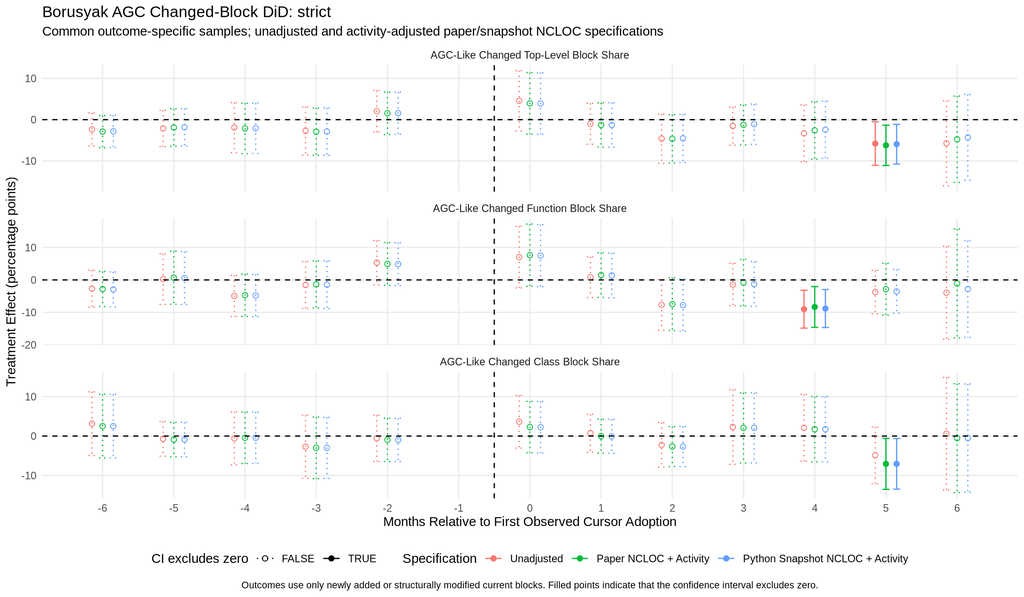

```r
if (nrow(dynamic_df) > 0) {
  dynamic_plot_data <- copy(as.data.table(dynamic_df))
  dynamic_plot_data[, outcome_label := factor(
    outcome_label,
    levels = outcome_definitions$outcome_label
  )]
  dynamic_plot_data[, specification_label := factor(
    specification_label,
    levels = specification_definitions$specification_label
  )]

  position <- position_dodge(width = 0.45)

  dynamic_plot <- ggplot(
    dynamic_plot_data,
    aes(
      x = time,
      y = estimate_percentage_points,
      color = specification_label,
      group = specification_label
    )
  ) +
    geom_errorbar(
      aes(
        ymin = conf_low_percentage_points,
        ymax = conf_high_percentage_points,
        linetype = significant
      ),
      position = position,
      width = 0.3
    ) +
    geom_point(
      aes(shape = significant),
      position = position,
      size = 1.8
    ) +
    geom_hline(yintercept = 0, linetype = "dashed") +
    geom_vline(xintercept = -0.5, linetype = "dashed") +
    scale_x_continuous(breaks = -6:6) +
    scale_shape_manual(
      values = c("TRUE" = 19, "FALSE" = 1),
      name = "CI excludes zero"
    ) +
    scale_linetype_manual(
      values = c("TRUE" = "solid", "FALSE" = "dotted"),
      name = "CI excludes zero"
    ) +
    facet_wrap(~ outcome_label, scales = "free_y", ncol = 1) +
    labs(
      title = paste("Borusyak AGC Changed-Block DiD:", panel_label),
      subtitle = paste(
        "Common outcome-specific samples; unadjusted and",
        "activity-adjusted paper/snapshot NCLOC specifications"
      ),
      x = "Months Relative to First Observed Cursor Adoption",
      y = "Treatment Effect (percentage points)",
      color = "Specification",
      caption = paste(
        "Outcomes use only newly added or structurally modified current blocks.",
        "Filled points indicate that the confidence interval excludes zero."
      )
    ) +
    theme_minimal() +
    theme(
      panel.grid.minor = element_blank(),
      legend.position = "bottom",
      plot.caption = element_text(hjust = 0.5, size = 8)
    )

  print(dynamic_plot)

  ggsave(
    filename = file.path(
      out_dir,
      "dynamic_effects_borusyak_agc_changed_block.pdf"
    ),
    plot = dynamic_plot,
    width = 12,
    height = 7
  )
} else {
  stop("No dynamic effects are available to plot.")
}
```

# 16 Model Metadata

```r
metadata <- data.frame(
  key = c(
    "script",
    "source_notebook",
    "helper_file",
    "panel_label",
    "panel_path",
    "validation_summary_path",
    "validation_status",
    "validation_checks_passed",
    "validation_checks_total",
    "out_dir",
    "outcomes",
    "primary_outcome",
    "specifications",
    "common_model_sample",
    "common_covariates",
    "activity_covariates",
    "activity_covariate_scaling",
    "activity_adjustment_interpretation",
    "adjusted_first_stage_formula",
    "unadjusted_first_stage_formula",
    "time_encoding",
    "dynamic_horizon",
    "pretrend_horizon",
    "weighting",
    "outcome_scale",
    "agc_definition",
    "hwc_definition",
    "changed_block_definition",
    "interpretation",
    "stock_baseline",
    "limitation"
  ),
  value = c(
    "proc_r/DiffInDiffBorusyak_AGC_ChangedBlock.Rmd",
    "DiffInDiffBorusyak_AGC.Rmd",
    params$helper_file,
    panel_label,
    panel_path,
    validation_summary_path,
    validation_summary$status,
    validation_summary$checks_passed,
    validation_summary$checks_total,
    out_dir,
    paste(outcome_definitions$outcome, collapse = ", "),
    "agc_changed_top_level_block_ratio",
    paste(specification_definitions$specification, collapse = ", "),
    paste(
      "Each outcome uses one common complete-case sample across all three",
      "specifications so estimates are directly comparable."
    ),
    paste(common_covariates, collapse = ", "),
    "commits, lines_added",
    "log1p(commits), log1p(lines_added)",
    paste(
      "Adjusted specifications condition on contemporaneous monthly",
      "development activity. Because commits and lines_added may respond",
      "to adoption, these estimates are interpreted as conditional",
      "sensitivity analyses rather than the total treatment effect."
    ),
    paste(
      deparse(build_first_stage_formula("paper_ncloc")),
      collapse = " "
    ),
    paste(
      deparse(build_first_stage_formula("unadjusted")),
      collapse = " "
    ),
    "sequential calendar-month id",
    "-6 through +6 months",
    "-6 through -2 months",
    "unweighted repository-month analysis",
    "proportion; reported as percentage points",
    "AGC = AI likely generated code",
    "HWC = Human likely written code",
    paste(
      "Current top-level functions/classes classified as added or",
      "structurally modified relative to the preceding monthly snapshot;",
      "unchanged, moved-unchanged, and deleted blocks are excluded."
    ),
    paste(
      "Change in the repository-month AGC-like share among newly added or",
      "structurally modified top-level Python function and class blocks",
      "after observed Cursor adoption."
    ),
    paste(
      "The stock-based analysis of accumulated repository snapshots is",
      "retained as a separate baseline estimand."
    ),
    paste(
      "The detector outcome captures structural similarity to AI-generated",
      "code and does not establish block provenance or tool identity."
    )
  ),
  stringsAsFactors = FALSE
)

print(metadata)
```

```
##                                   key
## 1                              script
## 2                     source_notebook
## 3                         helper_file
## 4                         panel_label
## 5                          panel_path
## 6             validation_summary_path
## 7                   validation_status
## 8            validation_checks_passed
## 9             validation_checks_total
## 10                            out_dir
## 11                           outcomes
## 12                    primary_outcome
## 13                     specifications
## 14                common_model_sample
```

[output cut: 49 more lines]

```r
fwrite(
  metadata,
  file.path(out_dir, "borusyak_agc_changed_block_model_metadata.csv")
)
```